# tss-uncertainty

A.J. Brown

2023-12-19

# Bayesian Inference for TSS Measurement Uncertainty

By A.J. Brown Agricultural Data Scientist ansleybrown1337@gmail.com [Personal Website](https://sites.google.com/view/ansleyjbrown/)

Description: This script is used to perform Bayesian inference on TSS using the NIMBLE package in R. For more information please view the README.md file in the root directory of [this repository](https://github.com/ansleybrown1337/bayes-tss-uncertainty).

## Load packages and data

```r
# Set working directory to repo parent folder
# Remember to make the knit button knit from current working directory
#setwd('../')
```

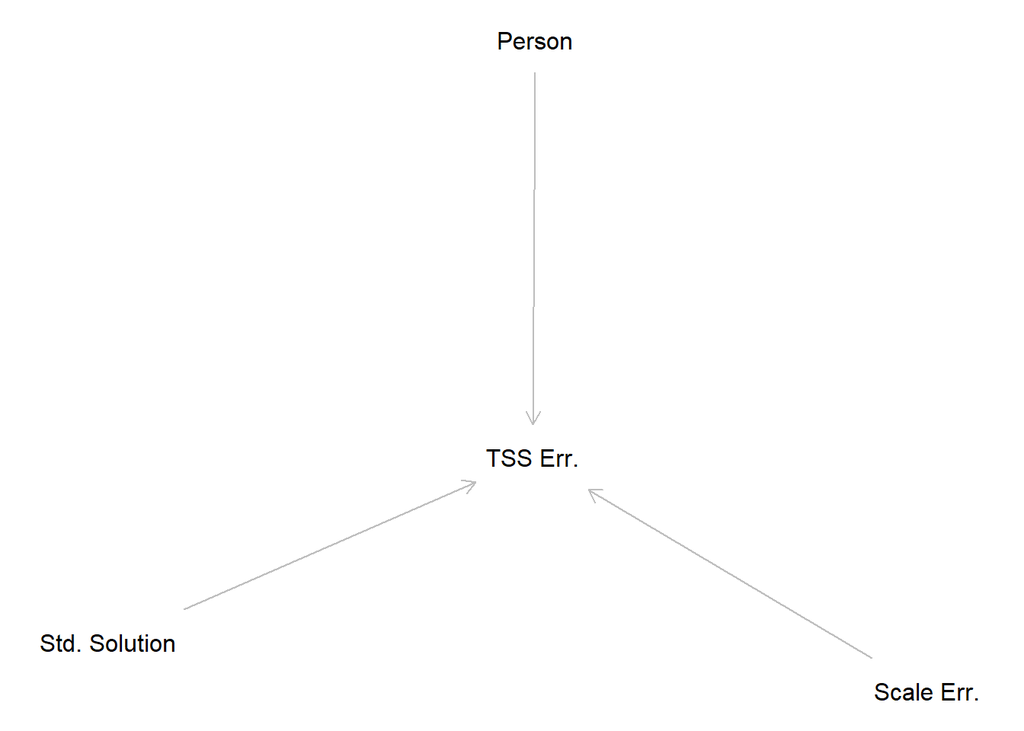

```r
# Create DAG from https://www.dagitty.net/
g <- dagitty('dag{
  bb="-3.196,-3.548,3.094,2.204"
  "Scale Err." [latent,pos="2.570,1.704"]
  "Std. Solution" [exposure,pos="-2.672,1.349"]
  "TSS Err." [outcome,pos="0.043,-0.004"]
  Person [exposure,pos="0.059,-3.048"]
  "Scale Err." -> "TSS Err."
  "Std. Solution" -> "TSS Err."
  Person -> "TSS Err."
}'
)
plot(g)
```

```r
# Load data
tss_df <- read.csv('../Example Data/TSS_Master_2023.csv')
```

```r
# Process data
  # separate data into two dataframes: standards and real data
std_list <- c('Stock Solution', 'DI')
std_df <- tss_df %>% filter(Sample_ID %in% std_list)
real_df <- tss_df %>% filter(!Sample_ID %in% std_list)

  # calculate error column for standards and center it
std_df <- std_df %>% mutate(
  tss.err = ifelse(Sample_ID == 'Stock Solution', 100-TSS_mg.L, 0-TSS_mg.L)
  )

  # change our categorical columns of interest into numbers
std_df$Sample_ID.num <- as.numeric(as.factor(std_df$Sample_ID))
std_df$Lab_technicians.num <- as.numeric(as.factor(std_df$Lab_technicians))

  # center our error
std_df$tss.err.ctr <- std_df$tss.err - mean(std_df$tss.err)
```

## Defining our model

We will use simple linear regression to estimate measurement error. I will assume the following form:
$$TSSerr_{i} = \alpha_k + \beta_{1, k} * person_k + \epsilon$$
Where: - $TSSerr_{i}$ is the error in TSS measurement $i$
- $\alpha_k$ is the intercept for person $k$
- $\beta_{1, k}$ is the coefficient for the person effect
- $\epsilon$ is the error term for TSS measurement

## Setting the model up in NIMBLE

### Step 1: Define the model

```r
# Step 1: Define the model
code <- nimbleCode({
  # Defining our priors
  alpha ~ dnorm(0, sd = 1) # intercept

  # Looping over the elements of person: they each get their own prior, and we will assume they are the same to start
  for(k in 1:3) {
    beta1[k] ~ dnorm(0, sd = 1)
  }

  sigma ~ dunif(0, 100) # prior for variance components based on Gelman (2006)

  # Defining our linear model
  for(i in 1:n) {
    err[i] ~ dnorm(alpha + beta1[person[i]], sd = sigma)
  }
})

constants <- list(
  n = nrow(std_df),
  person = std_df$Lab_technicians.num
  )

data <- list(
  err = std_df$tss.err
  ) # also try using std_df$tss.err.ctr

inits <- list(
  alpha = mean(std_df$tss.err),
  beta1 = rep(0, 3),
  sigma = 1
  )

model <- nimbleModel(
  code,
  constants = constants,
  data = data,
  inits = inits
  ) # build model
```

```
## Defining model
```

```
## Building model
```

```
## Setting data and initial values
```

```
## Running calculate on model
##   [Note] Any error reports that follow may simply reflect missing values in model variables.
```

```
## Checking model sizes and dimensions
```

### Step 2: Build the MCMC

```r
#mcmcErr <- configureMCMC(model) # assign default samplers to nodes
# Step 2: Build the MCMC
TSSmcmc <- buildMCMC(model, enableWAIC = TRUE)
```

```
## ===== Monitors =====
## thin = 1: alpha, beta1, sigma
## ===== Samplers =====
## RW sampler (1)
##   - sigma
## conjugate sampler (4)
##   - alpha
##   - beta1[]  (3 elements)
```

### Step 3: Compile the model and MCMC into C++ using Rtools

```r
# Step 3a: Compile the model
cTSSmodel <- compileNimble(model,showCompilerOutput = FALSE)
```

```
## Compiling
##   [Note] This may take a minute.
##   [Note] Use 'showCompilerOutput = TRUE' to see C++ compilation details.
```

```r
# Step 3b: Compile the MCMC
cTSSmcmc <- compileNimble(TSSmcmc, project = model)
```

```
## Compiling
##   [Note] This may take a minute.
##   [Note] Use 'showCompilerOutput = TRUE' to see C++ compilation details.
```

### Step 4: Run the MCMC

```r
# Step 4: Run the MCMC
time_baseline <- system.time(
  TSSresults <- runMCMC(cTSSmcmc,
                        niter=11000,
                        nburnin=1000, # change to 0 if you want to see burn in
                        WAIC=TRUE,
                        nchains=2)
  )
```

```
## running chain 1...
```

```
## |-------------|-------------|-------------|-------------|
## |-------------------------------------------------------|
```

```
## running chain 2...
```

```
## |-------------|-------------|-------------|-------------|
## |-------------------------------------------------------|
##   [Warning] There are 1 individual pWAIC values that are greater than 0.4. This may indicate that the WAIC estimate is unstable (Vehtari et al., 2017), at least in cases without grouping of data nodes or multivariate data nodes.
```

```r
cat("Sampling time: ", time_baseline[3], "seconds.\n")
```

```
## Sampling time:  2.2 seconds.
```

### Step 5: Extract the samples and WAIC

```r
# Step 5: Extract the samples and WAIC
  # Samples (default to 1st chain, 2nd is for convergence diagnostics)
samples <- TSSresults$samples$chain1
#colnames(samples)
summary(samples)
```

```
##      alpha            beta1[1]          beta1[2]          beta1[3]
##  Min.   :-2.2694   Min.   :-2.9147   Min.   :-3.0467   Min.   :-2.6200
##  1st Qu.:-0.2366   1st Qu.:-0.8188   1st Qu.:-0.2108   1st Qu.:-0.3500
##  Median : 0.1666   Median :-0.3520   Median : 0.3899   Median : 0.1242
##  Mean   : 0.1716   Mean   :-0.3558   Mean   : 0.3888   Mean   : 0.1273
##  3rd Qu.: 0.5846   3rd Qu.: 0.1069   3rd Qu.: 0.9782   3rd Qu.: 0.6052
##  Max.   : 2.5722   Max.   : 2.5761   Max.   : 3.6245   Max.   : 2.7768
##      sigma
##  Min.   :3.168
##  1st Qu.:3.907
##  Median :4.113
##  Mean   :4.130
##  3rd Qu.:4.340
##  Max.   :5.603
```

```r
  # Watanabe-Akaike Information Criterion (WAIC): captures model fit
  # Log Pointwise Predictive Density (LPPD): captures model complexity
  # effective number of parameters in the model (pWAIC): balances previous two
  # The relationship: WAIC=−2×lppd+2×pWAIC
WAIC <- TSSresults$WAIC
cat("  \n\nWAIC Results:\n\n")  # Two spaces before \n\n
```

```
##
##
## WAIC Results:
```

```r
WAIC
```

```
## nimbleList object of type waicNimbleList
## Field "WAIC":
## [1] 484.281
## Field "lppd":
## [1] -238.6588
## Field "pWAIC":
## [1] 3.481639
```

### Step 6: Inspect Convergence

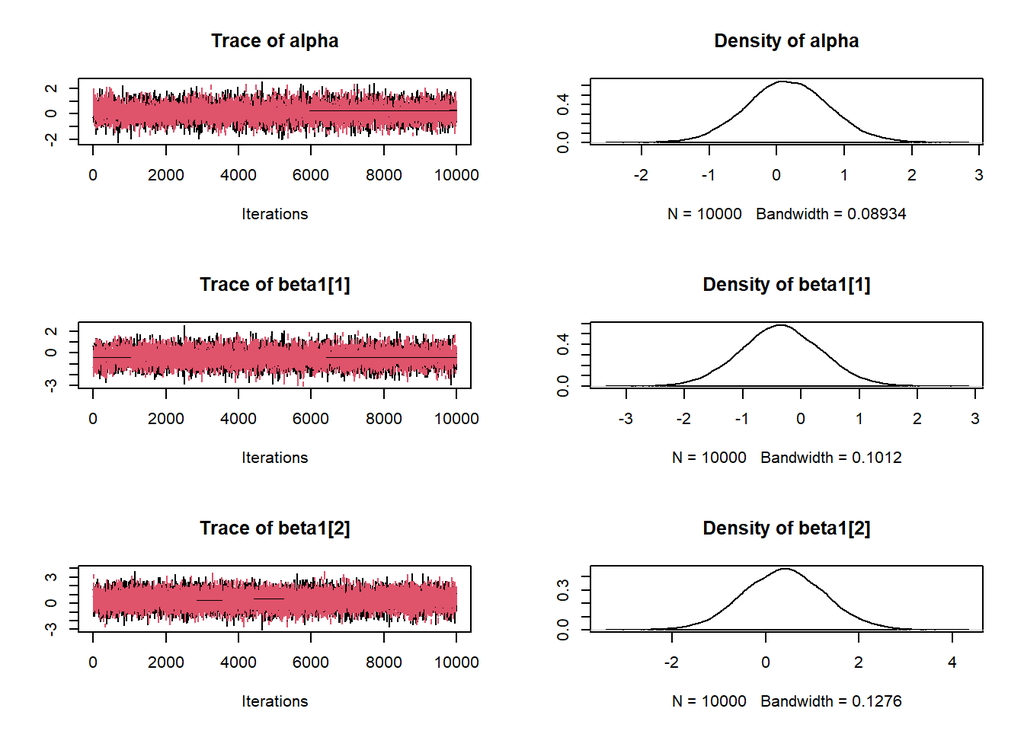

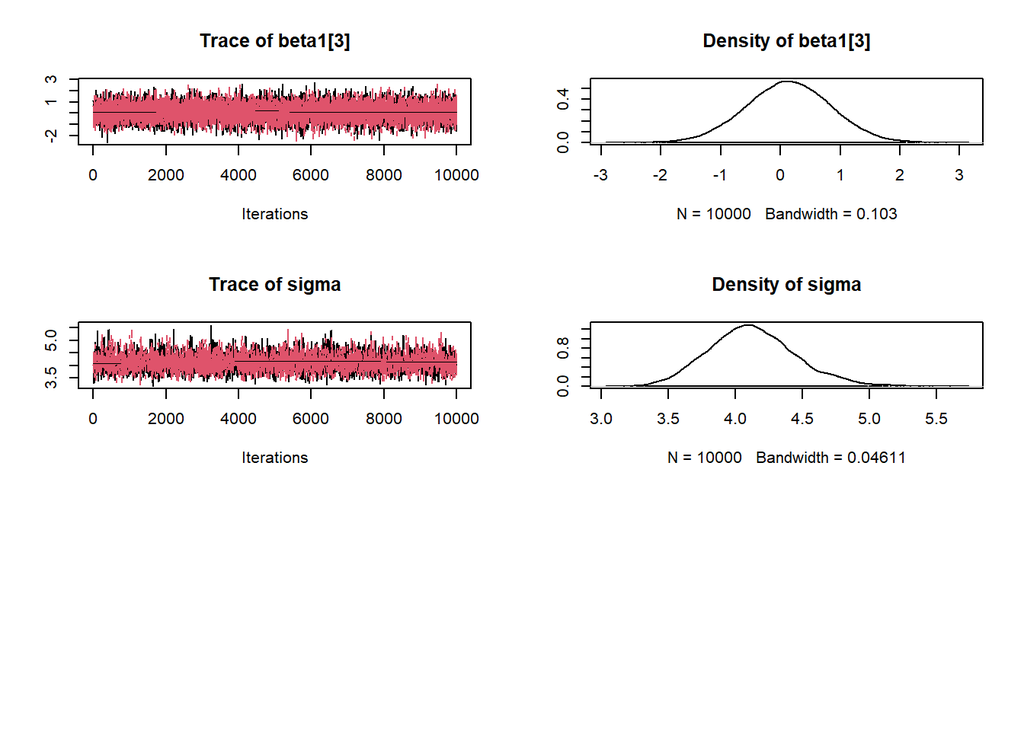

```r
# Step 6: Inspect Convergence
  # Using coda and BayesianTools packages
  # has to be pdf to capture all output
pdf('../Output/trace_density_plots.pdf')
plot(as.mcmc(samples))
dev.off()

png('../Output/correlation_plots.png')
correlationPlot(samples)
dev.off()

png('../Output/marginal_plot.png')
marginalPlot(samples)
dev.off()

# use gelman diag plots to compare chains
# see: https://theoreticalecology.wordpress.com/2011/12/09/mcmc-chain-analysis-and-convergence-diagnostics-with-coda-in-r/

combinedchains = mcmc.list(
  as.mcmc(TSSresults$samples$chain1),
  as.mcmc(TSSresults$samples$chain2)
  )

png('../Output/gelman_plot.png')
gelman.plot(combinedchains)
dev.off()

plot(combinedchains)
```

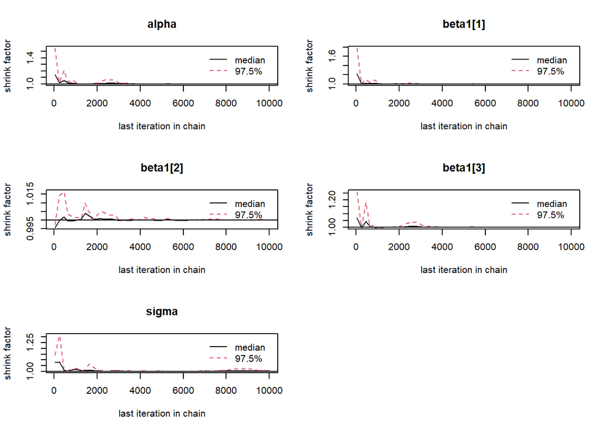

```r
gelman.diag(combinedchains)
gelman.plot(combinedchains)
```

[output not shown]

The gelman.diag gives you the scale reduction factors for each parameter. A factor of 1 means that between variance and within chain variance are equal, larger values mean that there is still a notable difference between chains. Often, it is said that everything below 1.1 or so is OK, but note that this is more a rule of thumb. The gelman,plot shows you the development of the scale-reduction over time (chain steps), which is useful to see whether a low chain reduction is also stable (sometimes, the factors go down and then up again, as you will see). Also, note that for any real analysis, you have to make sure to discard any bias that arises from the starting point of your chain (burn-in), typical values here are a few 1000-10000 steps. The gelman plot is also a nice tool to see roughly where this point is, that is, from which point on the chains seem roughly converged.

## Posterior Predictive Sampling

### Create a nimbleFunction to simulate new datasets

```r
# https://r-nimble.org/nimbleExamples/posterior_predictive.html
# Create a nimbleFunction to simulate new datasets
ppSamplerNF <- nimbleFunction(
          setup = function(model, mcmc) {
              dataNodes <- model$getNodeNames(dataOnly = TRUE)
              parentNodes <- model$getParents(dataNodes, stochOnly = TRUE)
              cat("Stochastic parents of data are:\n", paste(parentNodes, collapse = ','), "\n\n")
              simNodes <- model$getDependencies(parentNodes, self = FALSE)
              vars <- mcmc$mvSamples$getVarNames()  # need ordering of variables in mvSamples / samples matrix
              cat("Using posterior samples of:\n", paste(vars, collapse = ','), "\n\n")
              n <- length(model$expandNodeNames(dataNodes, returnScalarComponents = TRUE))
          },
          run = function(samples = double(2)) {
              nSamp <- dim(samples)[1]
              ppSamples <- matrix(nrow = nSamp, ncol = n)
              for(i in 1:nSamp) {
                    values(model, vars) <<- samples[i, ]
                    model$simulate(simNodes, includeData = TRUE)
                    ppSamples[i, ] <- values(model, dataNodes)
              }
              returnType(double(2))
              return(ppSamples)
          }
          )

# Run the function on our data
## Create the sampler for this model and this MCMC.
ppSampler <- ppSamplerNF(model, TSSmcmc)
```

```
## Stochastic parents of data are:
##  alpha,beta1[1],beta1[2],beta1[3],sigma
##
## Using posterior samples of:
##  alpha,beta1,sigma
```

### Compile the nimbleFunction into C++

```r
cppSampler <- compileNimble(ppSampler, project = model)
```

```
## Compiling
##   [Note] This may take a minute.
##   [Note] Use 'showCompilerOutput = TRUE' to see C++ compilation details.
```

### Run the nimbleFunction and get sample predictions

```r
ppSamples <- cppSampler$run(samples)
```

### Doing the posterior predictive checks

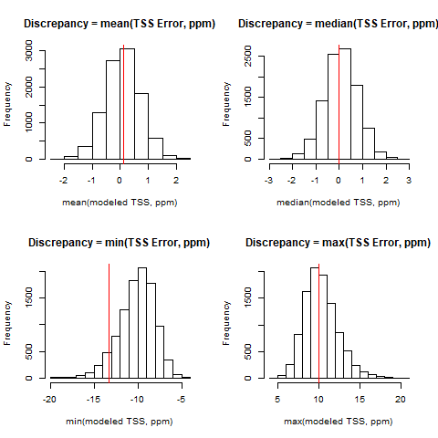

```r
png('../Output/posterior_pred_plots.png')
# Define a list of statistics to calculate
statsList <- list(
  mean = list(func = mean, obs = mean(std_df$tss.err)),
  median = list(func = median, obs = median(std_df$tss.err)),
  min = list(func = min, obs = min(std_df$tss.err)),
  max = list(func = max, obs = max(std_df$tss.err))
)

# Setting up a 2x2 plotting area
par(mfrow = c(2, 2))

# Loop through each statistic
for (statName in names(statsList)) {
  # Calculate the statistic for each row in ppSamples
  ppStat <- apply(ppSamples, 1, statsList[[statName]]$func)

  # Create the histogram
  hist(ppStat,
       main = sprintf("Discrepancy = %s(TSS Error, ppm)", statName),
       xlab = sprintf("%s(modeled TSS, ppm)", statName),
       col = rainbow(length(statsList))[statName])

  # Add observed value line
  abline(v = statsList[[statName]]$obs, col = 'red')
}
# Resetting plotting area to default
par(mfrow = c(1, 1))

dev.off()
```

Overall, it would appear that our model captures the TSS error well. The bulk of our predicted samples align closely with each observed value (i.e., the red line) for mean, median, and max. However, the observed min seems to be on the lower tail of our predicted distribution, indicating that our model may not simulate the lower error values as well. This could be due to the little number of observed samples at lower (i.e. more negative) values. The bulk of our values lie near zero, making this harder to simulate without more data.

## Inspect beta differences and impacts on error

Now that we are fairly confident in our model’s ability to simulate the TSS error, we can start to look at the differences between lab technician prowess by simulating errors by person and comparing distributions using the original model:

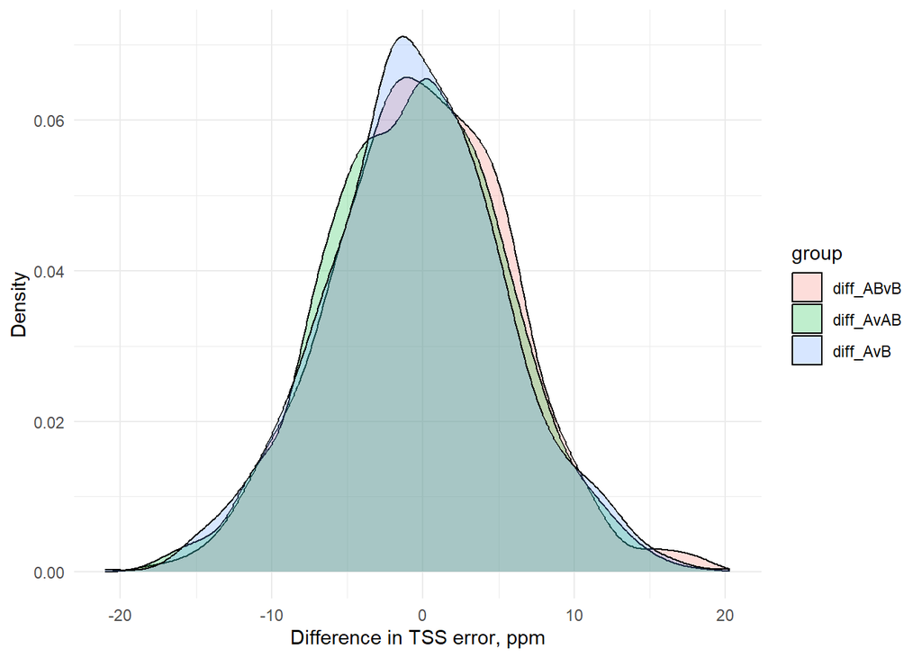

```r
# posterior W distributions to simulate TSS error by person
samples_df <- as.data.frame(samples)
errA <- rnorm(1000, samples_df$alpha + samples_df$`beta1[1]`, samples_df$sigma)
errAB <- rnorm(1000, samples_df$alpha + samples_df$`beta1[2]`, samples_df$sigma)
errB <- rnorm(1000, samples_df$alpha + samples_df$`beta1[3]`, samples_df$sigma)

diff_AvAB <- errA - errAB
diff_AvB <- errA - errB
diff_ABvB <- errAB - errB

# Create two separate data frames for errors and differences
errors_df <- data.frame(
  value = c(errA, errAB, errB),
  group = factor(c(rep("Person A", length(errA)),
                   rep("Person AB", length(errAB)),
                   rep("Person B", length(errB))))
)

diffs_df <- data.frame(
  value = c(diff_AvAB, diff_AvB, diff_ABvB),
  group = factor(c(rep("diff_AvAB", length(diff_AvAB)),
                   rep("diff_AvB", length(diff_AvB)),
                   rep("diff_ABvB", length(diff_ABvB))))
)

# Plot errors
plot_errors <- ggplot(errors_df, aes(x = value, fill = group)) +
  geom_density(alpha = 0.25) +
  labs(x = "TSS error, ppm", y = "Density") +
  theme_minimal()

# Plot differences
plot_diffs <- ggplot(diffs_df, aes(x = value, fill = group)) +
  geom_density(alpha = 0.25) +
  labs(x = "Difference in TSS error, ppm", y = "Density") +
  theme_minimal()

# Save plots as JPEG
ggsave('../Output/TSSerror_distributions.jpg', plot_errors, device = "jpeg")
ggsave('../Output/PersonDifference_distributions.jpg', plot_diffs, device = "jpeg")
plot_diffs
```

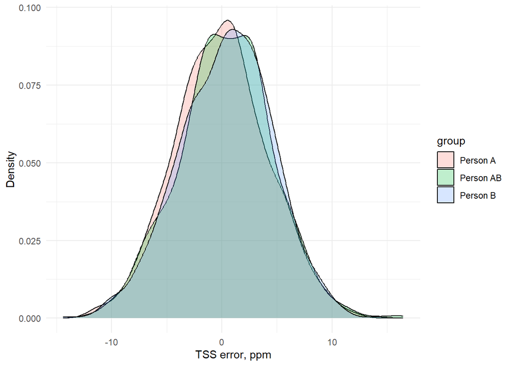

```r
plot_errors
```

```r
# Create a list containing all the vectors
all_vars <- list(errA = errA, errAB = errAB, errB = errB,
                 diff_AvAB = diff_AvAB, diff_AvB = diff_AvB, diff_ABvB = diff_ABvB)

# Loop through the list and print summary for each vector
for (var_name in names(all_vars)) {
  cat("Summary for", var_name, ":\n")
  print(summary(all_vars[[var_name]]))
  cat("\n") # For better readability
}
```

```
## Summary for errA :
##      Min.   1st Qu.    Median      Mean   3rd Qu.      Max.
## -11.80489  -2.93137  -0.03611  -0.06655   2.67419  12.21833
##
## Summary for errAB :
##     Min.  1st Qu.   Median     Mean  3rd Qu.     Max.
## -12.4128  -2.3295   0.4543   0.3628   3.0764  16.4556
##
## Summary for errB :
##     Min.  1st Qu.   Median     Mean  3rd Qu.     Max.
## -14.3977  -2.5408   0.6034   0.3887   3.2424  13.9460
##
## Summary for diff_AvAB :
##     Min.  1st Qu.   Median     Mean  3rd Qu.     Max.
## -17.2715  -4.4696  -0.2477  -0.4294   3.6281  18.2530
##
## Summary for diff_AvB :
##     Min.  1st Qu.   Median     Mean  3rd Qu.     Max.
## -21.0059  -4.2303  -0.6278  -0.4553   3.3696  20.3124
##
## Summary for diff_ABvB :
##      Min.   1st Qu.    Median      Mean   3rd Qu.      Max.
## -17.98360  -4.02031  -0.02192  -0.02587   4.03162  18.50029
```

From here, let’s calculate the lower (2.5%) and upper (97.5%) bounds of the 95% credible intervals for each difference distribution, as well as the mean and median values.

```r
# Function to calculate the 95% credible interval, mean, and median
calc_stats <- function(df) {
  quantiles <- quantile(df$value, probs = c(0.025, 0.975))
  mean_val <- mean(df$value)
  median_val <- median(df$value)
  c(Lower = quantiles[1], Upper = quantiles[2], Mean = mean_val, Median = median_val)
}

# Apply the function to each group and create a data frame
stats_list <- lapply(split(diffs_df, diffs_df$group), calc_stats)

# Convert the list to a data frame
stats_df <- do.call(rbind, stats_list)
rownames(stats_df) <- names(stats_list)

# Reset the column names
colnames(stats_df) <- c("Lower_2.5", "Upper_97.5", "Mean", "Median")

# Convert row names to a column (Group)
stats_df <- data.frame(Group = rownames(stats_df), stats_df, row.names = NULL)

# Add a column to check if zero is in the interval
stats_df$Contains_Zero <- with(stats_df,
                               Lower_2.5 <= 0 & Upper_97.5 >= 0)

# View the statistics
print(stats_df)
```

```
##       Group Lower_2.5 Upper_97.5        Mean      Median Contains_Zero
## 1 diff_ABvB -11.50943   11.53893 -0.02587502 -0.02192283          TRUE
## 2 diff_AvAB -11.73262   11.26261 -0.42939274 -0.24771950          TRUE
## 3  diff_AvB -12.53734   11.69277 -0.45526776 -0.62777890          TRUE
```

Keeping in mind that the units for this table are in ppm (mg/L), the mean and median values for each difference are close to zero (< 1 ppm away). Additionally, the 95% credible intervals for all difference distributions contain zero. This indicates that all lab technicians are performing rather well, with very little difference between persons.

### Supplementary material

For this study, we only needed to look at the simulated TSS results as shown above. However, it’s also worth including the resulting samples and distributions for the intercept (i.e., $\alpha$) and person effect (i.e., $\beta$),

#### Intercept posterier distribution

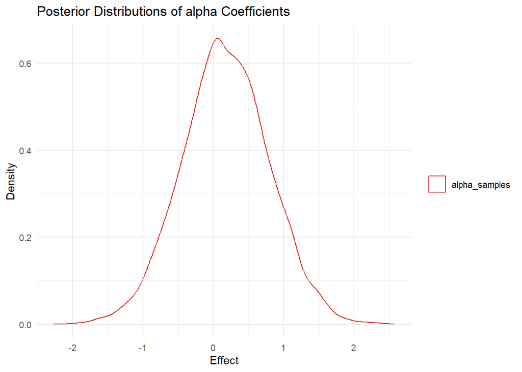

```r
# Get the beta2 samples from the sampler results
alpha_samples <- samples[ , grepl("alpha", colnames(samples))]
# Assuming beta2_samples is a matrix where each column represents a solution
alpha_df <- as.data.frame(alpha_samples)

# Convert to long format for ggplot
alpha_long_df <- alpha_df %>%
  mutate(iteration = row_number()) %>%
  pivot_longer(-iteration, names_to = "solution", values_to = "effect")

# Plot the posterior distributions of beta2
ax2 <-ggplot(alpha_long_df, aes(x = effect, color = solution)) +
  geom_density(alpha = 0, fill = NA) +  # No fill under the curve
  labs(title = "Posterior Distributions of alpha Coefficients",
       x = "Effect",
       y = "Density") +
  theme_minimal() +
  scale_color_brewer(palette = "Set1") +
  theme(legend.title = element_blank())
ax2
```

```r
ggsave('../Output/alpha_posterior_distributions.jpg', ax2)
summary(alpha_df)
```

```
##  alpha_samples
##  Min.   :-2.2694
##  1st Qu.:-0.2366
##  Median : 0.1666
##  Mean   : 0.1716
##  3rd Qu.: 0.5846
##  Max.   : 2.5722
```

#### Effect of person ($\beta_1$) on TSS error

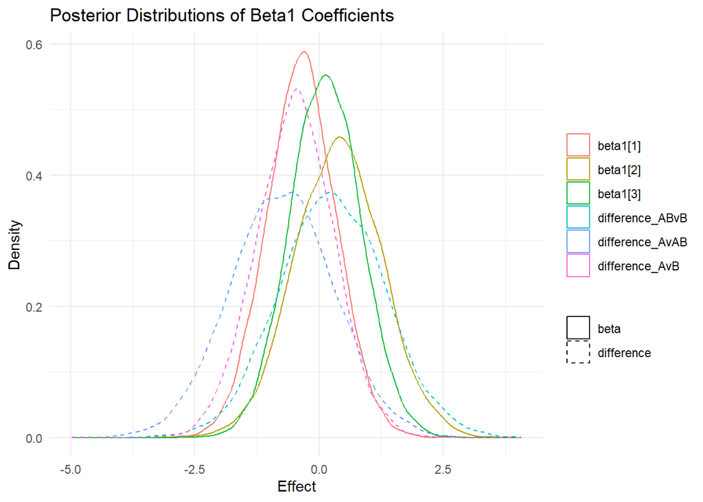

```r
# Get the beta1 samples from the sampler results
beta1_samples <- samples[ , grepl("beta1", colnames(samples))]

# Assuming beta1_samples is a matrix where each column represents a person
beta1_df <- as.data.frame(beta1_samples)
beta1_df$difference_AvAB <- beta1_df$`beta1[1]` - beta1_df$`beta1[2]`
beta1_df$difference_AvB <- beta1_df$`beta1[1]` - beta1_df$`beta1[3]`
beta1_df$difference_ABvB <- beta1_df$`beta1[2]` - beta1_df$`beta1[3]`

# Convert to long format for ggplot
beta1_long_df <- beta1_df %>%
  mutate(iteration = row_number()) %>%
  pivot_longer(-iteration, names_to = "person", values_to = "effect") %>%
  mutate(type = ifelse(grepl("difference", person), "difference", "beta"))

# Plot the posterior distributions of beta1
ax <- ggplot(beta1_long_df, aes(x = effect, color = person, linetype = type)) +
  geom_density() +  # Default color and fill
  scale_linetype_manual(values = c("solid", "dashed")) +  # Solid for beta, dashed for differences
  labs(title = "Posterior Distributions of Beta1 Coefficients",
       x = "Effect",
       y = "Density") +
  theme_minimal() +
  theme(legend.title = element_blank())
ax
```

```r
ggsave('../Output/beta1_posterior_distributions.jpg', ax)
summary(beta1_df)
```

```
##     beta1[1]          beta1[2]          beta1[3]       difference_AvAB
##  Min.   :-2.9147   Min.   :-3.0467   Min.   :-2.6200   Min.   :-4.97233
##  1st Qu.:-0.8188   1st Qu.:-0.2108   1st Qu.:-0.3500   1st Qu.:-1.45215
##  Median :-0.3520   Median : 0.3899   Median : 0.1242   Median :-0.74481
##  Mean   :-0.3558   Mean   : 0.3888   Mean   : 0.1273   Mean   :-0.74465
##  3rd Qu.: 0.1069   3rd Qu.: 0.9782   3rd Qu.: 0.6052   3rd Qu.:-0.04324
##  Max.   : 2.5761   Max.   : 3.6245   Max.   : 2.7768   Max.   : 3.27907
##  difference_AvB     difference_ABvB
##  Min.   :-3.34541   Min.   :-3.4638
##  1st Qu.:-1.00534   1st Qu.:-0.4481
##  Median :-0.47395   Median : 0.2559
##  Mean   :-0.48316   Mean   : 0.2615
##  3rd Qu.: 0.03582   3rd Qu.: 0.9797
##  Max.   : 2.74535   Max.   : 4.0645
```